# Image Clustering To Identify Stars' Surface Temperature

Look at the sky, go to any place with a low light pollution level and you will notice that it is full of stars. The stars show a multitude of colors and are not all the same because they do not all have identical temperatures. To define color precisely, astronomers have devised quantitative methods for characterizing the color of a star and then using those colors to determine stellar temperatures.  
The reason of different colors is explained by [Wien’s law](https://en.wikipedia.org/wiki/Wien's_displacement_law) and we know that it does not depend from the distance of stars, but it is related to radiation and wavelengths and it gives us insight about stars' surface temperature.  
In this article i will use R-CRAN and Clustering techniques for image processing in order to classify stars based on their spectrum and superficial temperature. All the images are free to use and can be taken from any astronomy website.

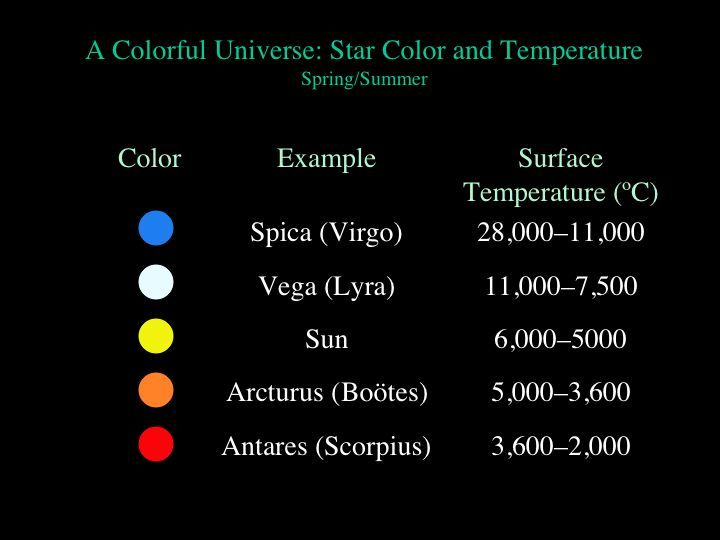

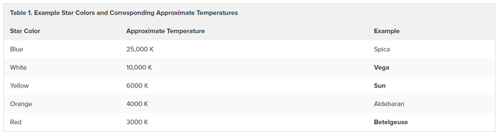

```r
library("IRdisplay")
display_jpeg(file = "spectrum2.jpg", width=500)
display_png(file = "Table.PNG")
```

First of all, i will load the libraries i need for the analysis.

```r
library(jpeg)
library(cluster)
```

In order to retrieve the information that i need for clustering, i will read the image's RGB (Red, Green, Blue) values. It will be useful later on to proceed to the color-distance calculation.  
In this case i select **VEGA** from the above table as my target and i display the image dimension (height, length)

```r
spica <- readJPEG("vega.jpg")
dimension <- dim(spica);dimension[1:2]
```

1. 800

2. 800

Now that i read the image, i will retrieve the RGB values that i need and plot the image from this values.

```r
RGBValues <- data.frame(
  x=rep(1:dimension[2], each=dimension[1]),
  y=rep(dimension[1]:1, dimension[2]),
  r.value=as.vector(spica[,,1]),
  g.value=as.vector(spica[,,2]),
  b.value=as.vector(spica[,,3]))
```

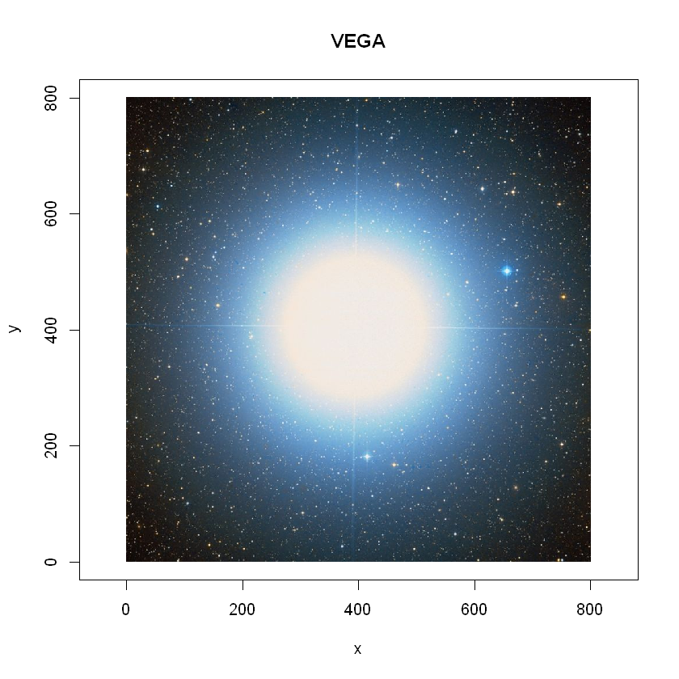

```r
plot(y ~ x, data=RGBValues, main="VEGA",
     col = rgb(RGBValues[c("r.value", "g.value", "b.value")]),
     asp = 1, pch = ".")
```

Once i have all the data, i need to determine the optimal number of clusters (k) for the image processing:

1. I will use [CLARA (Clustering LARge Applications) algorithm](https://en.wikibooks.org/wiki/Data_Mining_Algorithms_In_R/Clustering/CLARA) as the algorithm is indicated to cope with large datasets, in this case with all RGB values from the image.
2. I will test clusters(k) till k=10, and then for each k i will compare the average SILHOUETTE, that is essentially a value that express the k-cluster consistency and range from -1 (inconsistent) to +1 (consistent).

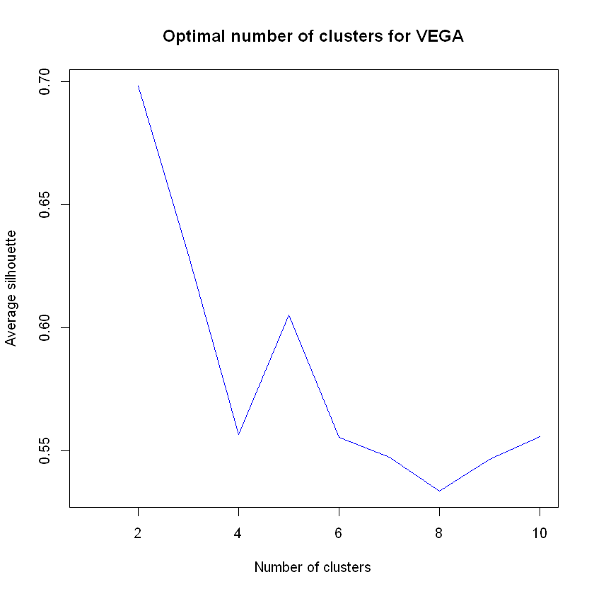

```r
var <- c()
for (k in 1:10) {
  clara_ <- clara(RGBValues[, c("r.value", "g.value", "b.value")], k)
  var[k] <- clara_$silinfo$avg.width
}

plot(var, type = 'l',
     main = "Optimal number of clusters for VEGA",
     xlab = "Number of clusters",
     ylab = "Average silhouette",
     col = "blue")
```

From the above chart we can see that the **optimal number of clusters is k=2.**  
This is because in the image we have to dominant colors: the star's color and the dark space color.  
Once i have the optimal k, I can run CLARA:

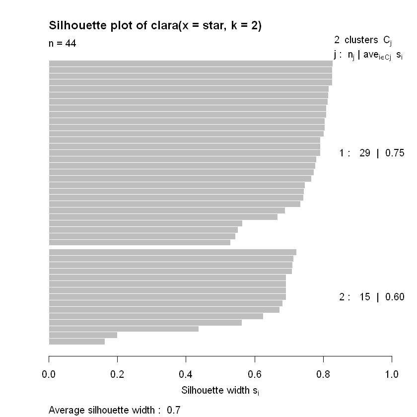

```r
star <- RGBValues[, c("r.value", "g.value", "b.value")]
clara <- clara(star, 2)
plot(silhouette(clara))
```

The silhouette value shows us that the **data is consistent** and we can proceed with our clustering.  
Now i can plot the clustered image:

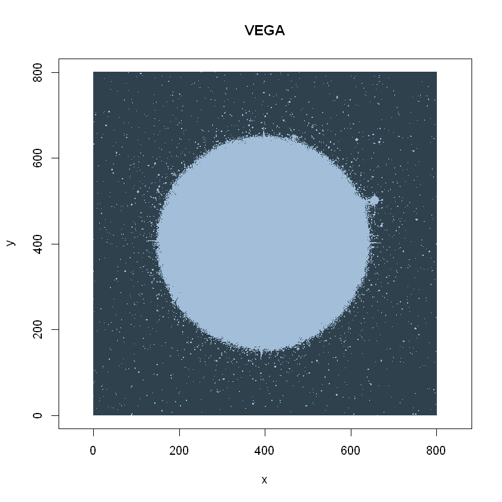

```r
colors <- rgb(clara$medoids[clara$clustering, ])
plot(y ~ x,
     data=RGBValues,
     main="VEGA",
     col = colors,
     asp = 1,
     pch = ".")
```

Then i can create a dataframe containing some information that i need for the analysis:

- **colors:** HEX values of the two dominant colors
- **Freq:** Frequency of each colour (in absolute terms)
- **distribution:** Frequency of each colour (in percentage terms)

```r
colors_data <- as.data.frame(table(colors))
colors_data$distribution <- round((((colors_data$Freq)/sum(colors_data$Freq)) * 100), 2)
colors_data
```

A data.frame: 2 × 3

| colors <fct> | Freq <int> | distribution <dbl> |
| --- | --- | --- |
| #2F414D | 436735 | 68.24 |
| #A3BED9 | 203265 | 31.76 |

And i can create a simple pie chart to show the two colors with their %distributions:

[figure not shown]

```r
colors_data$colors <- as.character(colors_data$colors)
pie(colors_data$Freq,
    labels = colors_data$distribution,
    col = colors_data$colors,
    xlab = "Colors",
    ylab = "Frequency")
```

## Colors Isolation

From the above pie chart I can see the first problem to solve: isolate the star's colour from the surrounding/background.

As images can seize different proportions of a star's surrounding, I can not simply create an algorithm that automatically exclude the color with an higher percentage in distribution (like in this case) because it's likely that an error will occurr and some false result will be provided as the algorithm output.

Here an example:

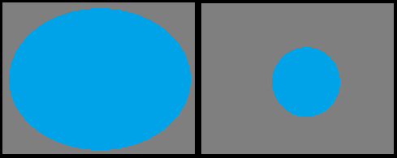

```r
display_png(file="error example.png")
```

In the above example, both pictures are displaying the same object but from different perspectives. In case I would implement an algorithm that would automatically exclude the color with an higher %distribution, in the first picture I will exclude the object that I want to analyze while in the second example I will exclude the surrounding.  
**To solve this, i created a function that retrieves the *brightness* of colors for a given RGB and from that we can exclude the darkest colour (because the space itself has no brightness, or has some residual brightness from the clustering depending on the quality of images)**  
In my dataframe i have colors expressed in HEX values and i will convert those into RGB values with a simple built-in function:

```r
hexToRgb <- function(x) {
    paste(as.vector(col2rgb(x)), collapse = " ")
}
```

Then i can create a function that return a color's brightness for a given RGB value using LUMA methodology):

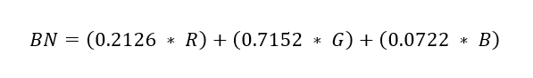

```r
display_png(file="BRFormula.PNG")
```

```r
getBrightness <- function(rgb) {
    vector <- unlist(strsplit(rgb, " "))
    r <- strtoi(vector[1])
    g <- strtoi(vector[2])
    b <- strtoi(vector[3])
    0.2126 * r + 0.7152 * g + 0.0722 * b
}
```

```r
colors_data$brightness <- unlist(lapply(lapply(colors_data$colors, hexToRgb), getBrightness))
```

Now I can display the colors' brightness and exclude the darkest one:

```r
color_to_analyze <- colors_data[colors_data$brightness == max(colors_data$brightness), ]$colors
colors_data
```

A data.frame: 2 × 4

| colors <chr> | Freq <int> | distribution <dbl> | brightness <dbl> |
| --- | --- | --- | --- |
| #2F414D | 436735 | 68.24 | 62.0396 |
| #A3BED9 | 203265 | 31.76 | 186.2092 |

## Colors Similarity

Now that I have the star's color, I need an algorithm that for a given color returns me the star's surface temperature (in Kelvin).  
Another thing to consider is that not all stars have the same shade of color, some can be dark blue and some light blue, and so on.  
My idea is to create a dataframe with the most 5 common colors and shades and the relative surface temperature, then for each star analyzed we evaluate its RGB values against the database's RGB values and we return the most similar:  
**1. Create Euclidean Distance function for RGB:**

```r
display_svg(file="euclidean_distance.svg")
```

[figure not shown]

```r
checkColorsDifference <- function(col1, col2) {
    vector1 <- unlist(strsplit(col1, " "))
    vector2 <- unlist(strsplit(col2, " "))
    r <- (strtoi(vector1[1]) - strtoi(vector2[1]))**2
    g <- (strtoi(vector1[2]) - strtoi(vector2[2]))**2
    b <- (strtoi(vector1[3]) - strtoi(vector2[3]))**2
    sqrt(r+g+b)
}
```

**2. Create Database of stars' colors and temperatures (in Kelvin). I used [this website](https://imagecolorpicker.com/en/) to retrieve RGB values from each star in the picture:**

```r
rgbColors <- c("30 125 241", "232 251 255", "179 176 7", "209 108 36", "194 6 10")
temperatures <- c("28000-18000", "11000-7500", "6000-5000", "5000-3600", "3600-2000")
db_data <- data.frame(rgbColors, temperatures)
db_data
```

A data.frame: 5 × 2

| rgbColors <chr> | temperatures <chr> |
| --- | --- |
| 30 125 241 | 28000-18000 |
| 232 251 255 | 11000-7500 |
| 179 176 7 | 6000-5000 |
| 209 108 36 | 5000-3600 |
| 194 6 10 | 3600-2000 |

**3. I check the similarity of my color with each color in the database:**

```r
db_data$matchColor <- unlist(lapply(db_data$rgbColors, checkColorsDifference, col1=hexToRgb(color_to_analyze)))
temperature <- db_data[db_data$matchColor == min(db_data$matchColor), ]$temperatures
db_data
```

A data.frame: 5 × 3

| rgbColors <chr> | temperatures <chr> | matchColor <dbl> |
| --- | --- | --- |
| 30 125 241 | 28000-18000 | 149.96666 |
| 232 251 255 | 11000-7500 | 99.62931 |
| 179 176 7 | 6000-5000 | 211.07345 |
| 209 108 36 | 5000-3600 | 203.96323 |
| 194 6 10 | 3600-2000 | 278.68620 |

```r
print(paste0("The star has a temperature between ", temperature, " K"))
```

```
[1] "The star has a temperature between 11000-7500 K"
```

Let's check on Google if the algorithm returns the correct temperature:

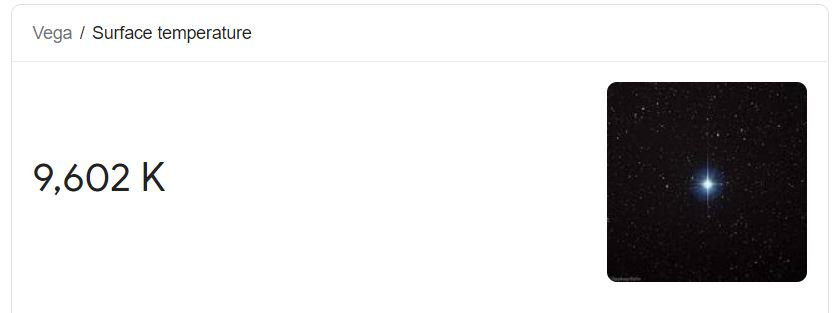

```r
display_jpeg(file="VegaTemperatureFromGoogle.JPG", width=550, height=200)
```

We see that **the clustering algorithm returns the right temperature's range.**  
Now let's try with our most familiar star: **THE SUN!**  
I will group all the lines in a single function to quickly test my algorithm and then i run it:

```r
checkTemperature <- function(star_file) {
    spica <- readJPEG(star_file)
    dimension <- dim(spica);dimension[1:2]
    RGBValues <- data.frame(
      x=rep(1:dimension[2], each=dimension[1]),
      y=rep(dimension[1]:1, dimension[2]),
      r.value=as.vector(spica[,,1]),
      g.value=as.vector(spica[,,2]),
      b.value=as.vector(spica[,,3]))
    plot(y ~ x, data=RGBValues, main="SUN",
     col = rgb(RGBValues[c("r.value", "g.value", "b.value")]),
     asp = 1, pch = ".")
    var <- c()
    for (k in 1:10) {
      clara_ <- clara(RGBValues[, c("r.value", "g.value", "b.value")], k)
      var[k] <- clara_$silinfo$avg.width
    }
    star <- RGBValues[, c("r.value", "g.value", "b.value")]
    clara <- clara(star, 2)
    colors <- rgb(clara$medoids[clara$clustering, ])
    colors_data <- as.data.frame(table(colors))
    colors_data$distribution <- round((((colors_data$Freq)/sum(colors_data$Freq)) * 100), 2)
    colors_data$colors <- as.character(colors_data$colors)
    colors_data$brightness <- unlist(lapply(lapply(colors_data$colors, hexToRgb), getBrightness))
    color_to_analyze <- colors_data[colors_data$brightness == max(colors_data$brightness), ]$colors
    rgbColors <- c("30 125 241", "232 251 255", "179 176 7", "209 108 36", "194 6 10")
    temperatures <- c("28000-18000", "11000-7500", "6000-5000", "5000-3600", "3600-2000")
    db_data <- data.frame(rgbColors, temperatures)
    db_data$matchColor <- unlist(lapply(db_data$rgbColors, checkColorsDifference, col1=hexToRgb(color_to_analyze)))
    temperature <- db_data[db_data$matchColor == min(db_data$matchColor), ]$temperatures

    print(paste0("The star has a temperature between ", temperature, " K"))
}
```

```
[1] "The star has a temperature between 6000-5000 K"
```

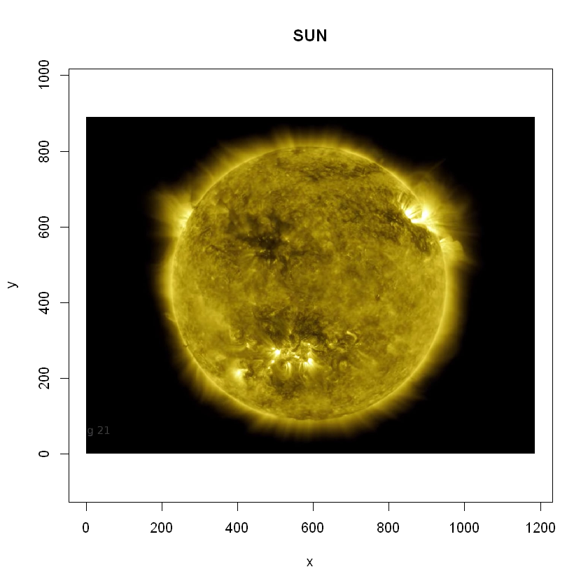

```r
checkTemperature("sun.jpg")
```

The algorithm produces another correct result as the Sun surface temperature is around **5,778 K**